# A song of ice and fire (books 1 to 5) network analysis

Rafaela Becerra

# 1 Ice of fire network 1

## 1.1 Packages needed

```r
library(igraph)
```

## 1.2 Load the file GoT.RData to R.

```r
setwd("C:/Users/Rafaela Becerra/Desktop/UC3M/Network_Analysis/Assignments/GOT")
load("GoT.RData")
got.network <- union_edges
```

## 1.3 Create the network.

```r
got.network <-graph_from_data_frame(union_edges,directed=TRUE,vertices=NULL)
```

```r
class(got.network)
```

```
## [1] "igraph"
```

The network contains characters of the books from the A song of ice and fire series, i.e., each vertex is a character.

```r
head(V(got.network))
```

```
## + 6/208 vertices, named, from 425c90b:
## [1] Lysa Arryn        Jasper Arryn      Jon Arryn         Cersei Lannister
## [5] Cassana Baratheon Selyse Florent
```

The edges corresponds to diferent type of relationships.

```r
head(as_edgelist(got.network))
```

```
##      [,1]               [,2]
## [1,] "Lysa Arryn"       "Robert Arryn"
## [2,] "Jasper Arryn"     "Alys Arryn"
## [3,] "Jasper Arryn"     "Jon Arryn"
## [4,] "Jon Arryn"        "Robert Arryn"
## [5,] "Cersei Lannister" "Tommen Baratheon"
## [6,] "Cersei Lannister" "Joffrey Baratheon"
```

The relationships possible are:

```r
unique(edge_attr(got.network)$type)
```

```
## [1] "mother"        "father"        "father/mother" "spouse"
```

The colors for the possible relationships given are:

[figure not shown]

```r
colors <- paste(unique(edge_attr(got.network)$color))
plot(x=1:4, y=rep(4,4), pch=19,cex=15,col=colors, xlim=c(0.75,4.5),axes=FALSE, ann=FALSE)
```

## 1.4 Order and size of the network.

```r
go<- gorder(got.network)
print(paste('The order is: ',go))
```

```
## [1] "The order is:  208"
```

```r
V(got.network)
```

```
## + 208/208 vertices, named, from 425c90b:
##   [1] Lysa Arryn
##   [2] Jasper Arryn
##   [3] Jon Arryn
##   [4] Cersei Lannister
##   [5] Cassana Baratheon
##   [6] Selyse Florent
##   [7] Rhaelle Targaryen
##   [8] Robert Baratheon
##   [9] Steffon Baratheon
##  [10] Stannis Baratheon
## + ... omitted several vertices
```

```r
gs<- gsize(got.network)
print(paste('The size is: ',gs))
```

```
## [1] "The size is:  404"
```

There are 208 characters and the relationships between them are represented by 404 edges.

## 1.5 Basic visual representation of the network and draw conclusions.

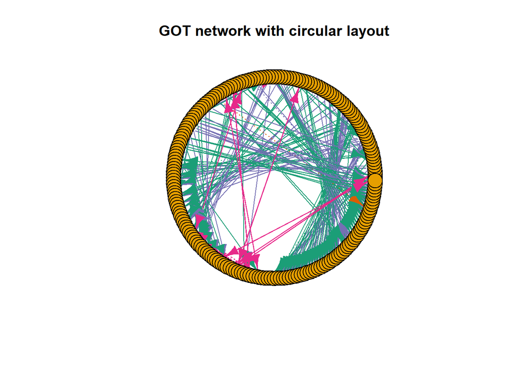

```r
plot.igraph(got.network,
            layout=layout_in_circle,
            vertex.label=NA,
            main="GOT network with circular layout")
```

By looking at the graph we can see that there are a lot of relationships of ‘father’, the second most common appears to be ‘mother’, third ‘spouse’ and finally ‘father/mother’, which in fact was specify as a mistake of the data set. Moreover, we have verified that the only relationship that it is valid in both ways will be ‘spouse’ which corresponds to the pink edges. Additionally, we can see that there are some vertex without connections, we will check this in the below sections.

# 2 Ice of fire network 2

## 2.1 Nneighbors and the incident edges of Cersei Lannister (vertex number 4).

```r
neighbors(got.network,4)
```

```
## + 4/208 vertices, named, from 425c90b:
## [1] Robert Baratheon   Tommen Baratheon   Joffrey Baratheon  Myrcella Baratheon
```

```r
incident(got.network,4)
```

```
## + 7/404 edges from 425c90b (vertex names):
## [1] Cersei Lannister->Robert Baratheon   Cersei Lannister->Tommen Baratheon
## [3] Cersei Lannister->Joffrey Baratheon  Cersei Lannister->Myrcella Baratheon
## [5] Robert Baratheon->Cersei Lannister   Joanna Lannister->Cersei Lannister
## [7] Tywin Lannister ->Cersei Lannister
```

##In, out and total degree of Cersei Lannister (vertex number 4).

```r
print(paste('The in degree is: ',degree(got.network,4,mode="in")))
```

```
## [1] "The in degree is:  3"
```

```r
print(paste('The out degree is: ',degree(got.network,4,mode="out")))
```

```
## [1] "The out degree is:  4"
```

```r
print(paste('The total degree is: ',degree(got.network,4,mode="total")))
```

```
## [1] "The total degree is:  7"
```

## 2.2 In, out and total degree sequence of the network.

- The in degree:

```r
head(degree(got.network,mode="in"))
```

```
##        Lysa Arryn      Jasper Arryn         Jon Arryn  Cersei Lannister
##                 4                 0                 4                 3
## Cassana Baratheon    Selyse Florent
##                 1                 1
```

```r
sum(degree(got.network,mode="in"))
```

```
## [1] 404
```

- The out degree:

```r
head(degree(got.network,mode="out"))
```

```
##        Lysa Arryn      Jasper Arryn         Jon Arryn  Cersei Lannister
##                 3                 2                 4                 4
## Cassana Baratheon    Selyse Florent
##                 4                 2
```

```r
sum(degree(got.network,mode="out"))
```

```
## [1] 404
```

- The total degree:

```r
head(degree(got.network,mode="total"))
```

```
##        Lysa Arryn      Jasper Arryn         Jon Arryn  Cersei Lannister
##                 7                 2                 8                 7
## Cassana Baratheon    Selyse Florent
##                 5                 3
```

```r
head(gsize(got.network))
```

```
## [1] 404
```

## 2.3 Average in, out and total degree of the network.

```r
print(paste('The average in degree is: ',mean(degree(got.network,mode="in"))))
```

```
## [1] "The average in degree is:  1.94230769230769"
```

```r
print(paste('The average out degree is: ',mean(degree(got.network,mode="out"))))
```

```
## [1] "The average out degree is:  1.94230769230769"
```

```r
print(paste('The average total degree is: ',gsize(got.network)/gorder(got.network)))
```

```
## [1] "The average total degree is:  1.94230769230769"
```

```r
getmode <- function(v) {
   uniqv <- unique(v)
   uniqv[which.max(tabulate(match(v, uniqv)))]
}
print(paste('The mode in degree is: ',getmode(degree(got.network,mode="in"))))
```

```
## [1] "The mode in degree is:  1"
```

```r
print(paste('The mode out degree is: ',getmode(degree(got.network,mode="out"))))
```

```
## [1] "The mode out degree is:  1"
```

We have checked that the values are the same and that the average degree is equal to the ratio of the size over the order of the network. We can say that each character is related with other two, approximately, and that the most common number of relationships with other characters is one.

## 2.4 In, out and total degree distribution of the network and draw conclusions.

- In degree distribution

Frequency table

```r
table(degree(got.network,mode="in"))
```

```
##
##  0  1  2  3  4  5
## 10 74 58 52 12  2
```

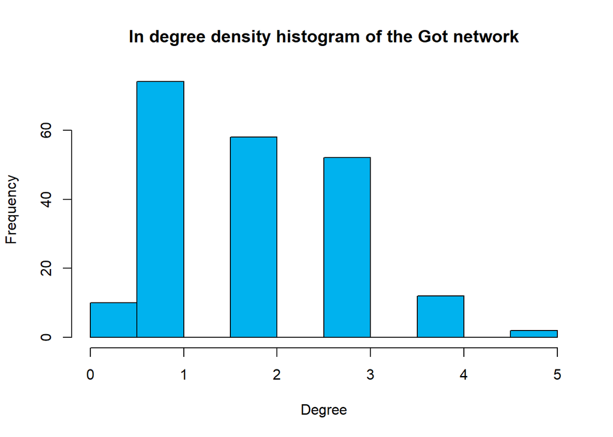

```r
hist(degree(got.network,mode="in"),
     col="deepskyblue2",
     main="In degree density histogram of the Got network",
     xlab="Degree",
     freq=TRUE)
```

Degree distribution

```r
degree_distribution(got.network,mode="in")
```

```
## [1] 0.048076923 0.355769231 0.278846154 0.250000000 0.057692308 0.009615385
```

Plot of the distribution

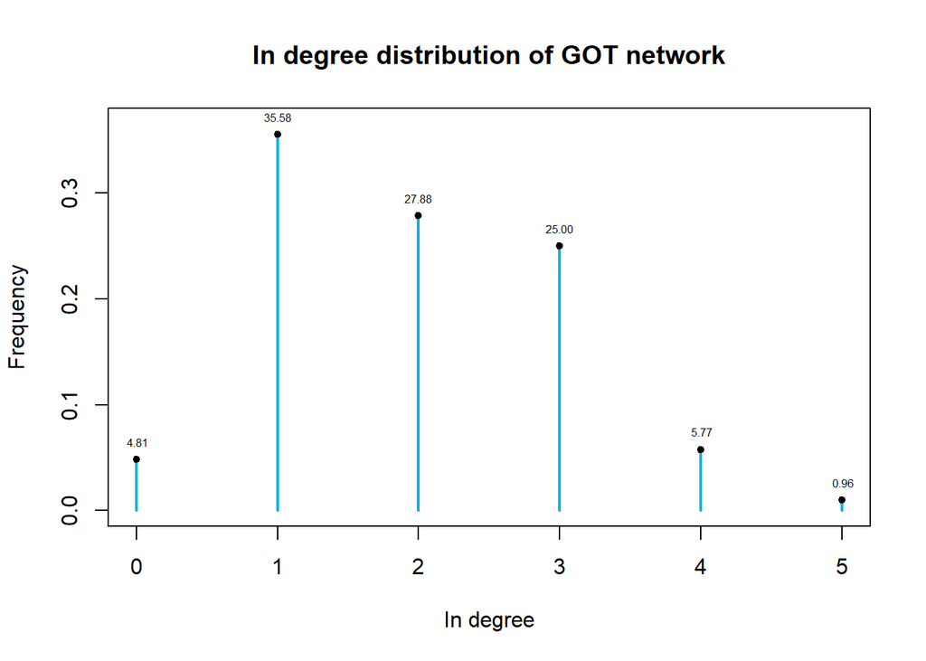

```r
plot(0:max(degree(got.network,mode="in")),
     degree_distribution(got.network,mode="in"),
     ylim=c(0,(max(degree_distribution(got.network,mode="in"))+0.01)),
     col="deepskyblue2",lwd=2,
     main="In degree distribution of GOT network",
     xlab="In degree",
     ylab="Frequency",
     type="h")
points(0:max(degree(got.network,mode="in")),
       degree_distribution(got.network,mode="in"),
       pch=20)
text(0:max(degree(got.network,mode="in")),
     degree_distribution(got.network,mode="in"),
     labels=format(100*degree_distribution(got.network,mode="in"), digits=2), cex=0.5, font=1, pos=3)
```

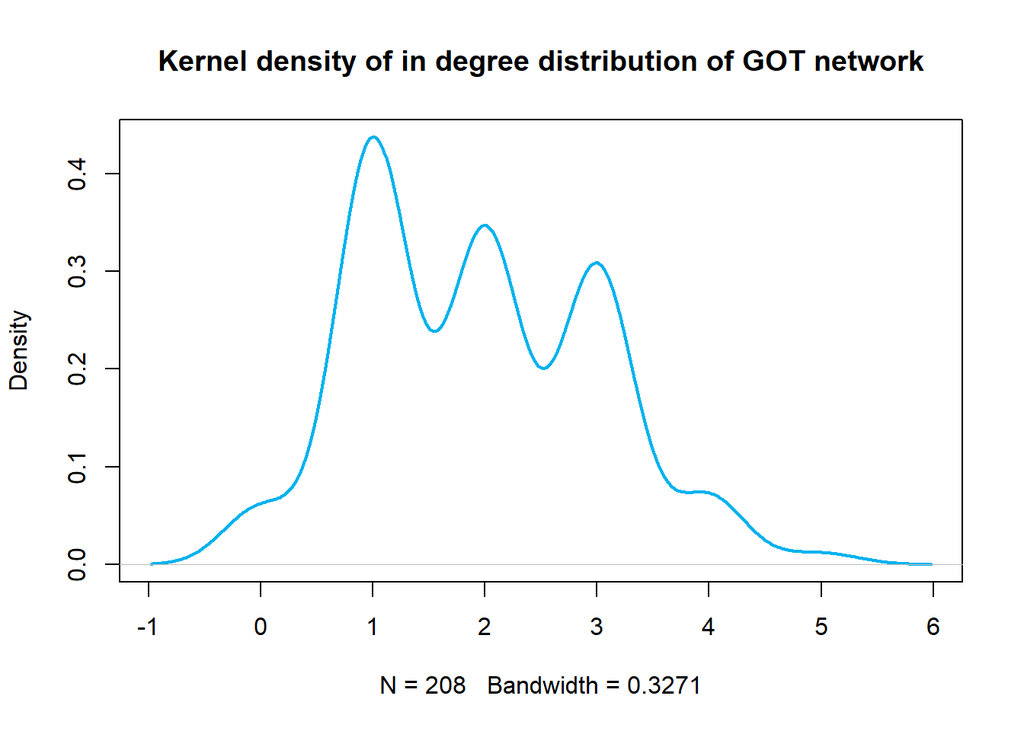

```r
plot(density(degree(got.network,mode="in")),
     col="deepskyblue2",lwd=2,
     main="Kernel density of in degree distribution of GOT network")
```

- Out degree distribution

Frquency table

```r
table(degree(got.network,mode="out"))
```

```
##
##  0  1  2  3  4  5  6  7  9 10 12
## 54 59 26 26 23 11  5  1  1  1  1
```

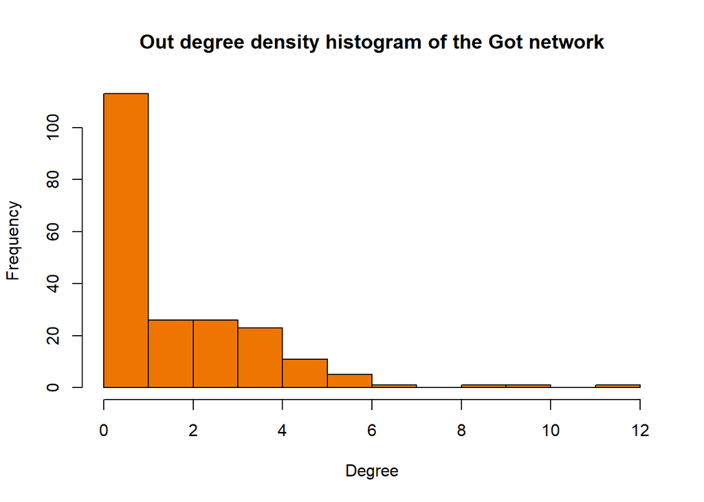

```r
hist(degree(got.network,mode="out"),
     col="darkorange2",
     main="Out degree density histogram of the Got network",
     xlab="Degree",
     freq=TRUE)
```

Degree distribution

```r
degree_distribution(got.network,mode="in")
```

```
## [1] 0.048076923 0.355769231 0.278846154 0.250000000 0.057692308 0.009615385
```

Plot of the distribution

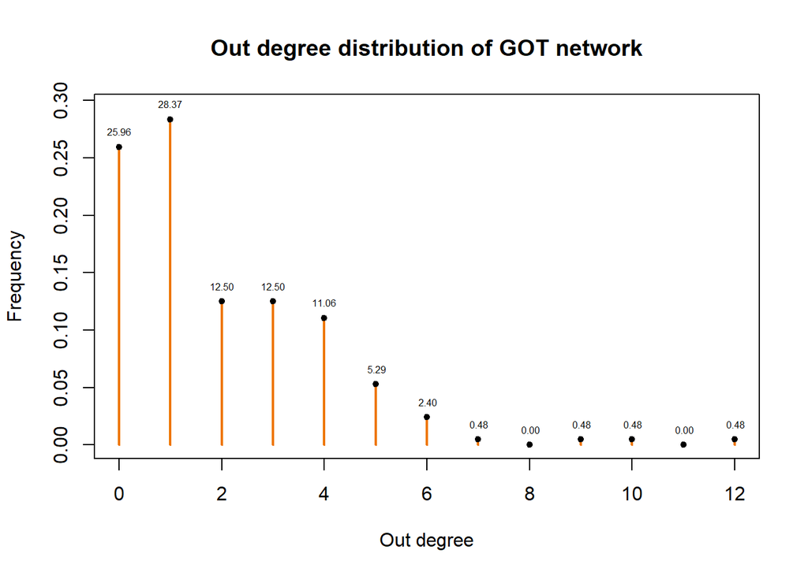

```r
plot(0:max(degree(got.network,mode="out")),
     degree_distribution(got.network,mode="out"),
     ylim=c(0,(max(degree_distribution(got.network,mode="out"))+0.01)),
     col="darkorange2",lwd=2,
     main="Out degree distribution of GOT network",
     xlab="Out degree",
     ylab="Frequency",
     type="h")
points(0:max(degree(got.network,mode="out")),
       degree_distribution(got.network,mode="out"),
       pch=20)
text(0:max(degree(got.network,mode="out")),
     degree_distribution(got.network,mode="out"),
     labels=format(100*degree_distribution(got.network,mode="out"), digits=2), cex=0.5, font=1, pos=3)
```

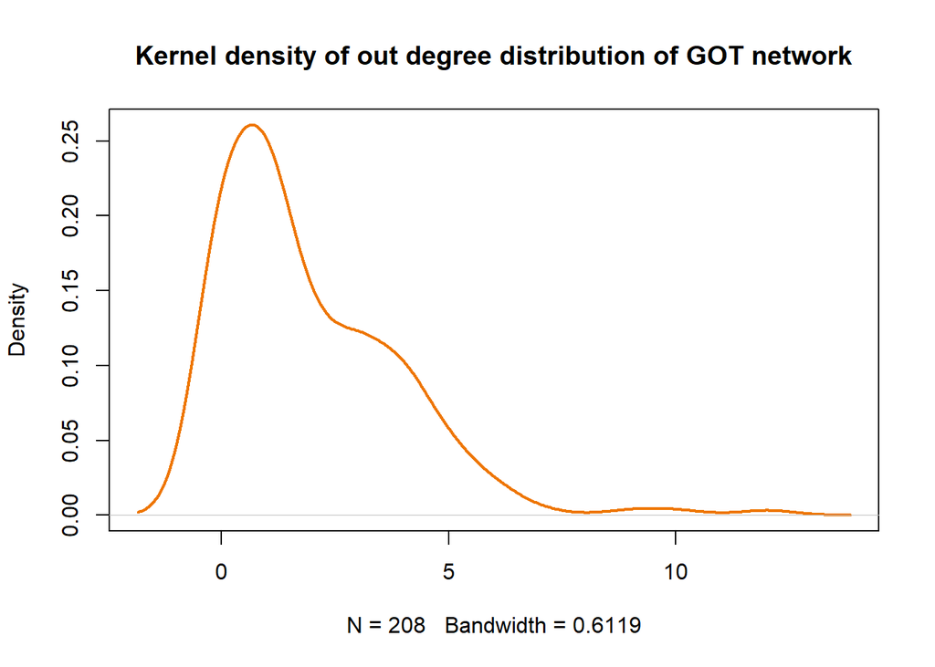

```r
plot(density(degree(got.network,mode="out")),
     col="darkorange2",lwd=2,
     main="Kernel density of out degree distribution of GOT network")
```

The degree corresponds to the number of edges incident on a vertex, which in this case corresponds to the number of characters among all which each character relates. Given that this network involves directed connections we have two types ‘in’ and ‘out’ relations. We have calculated the frequency of these connections and also the their degree distribution, which is constructed by the probabilities that a selected vertex in the network has a degree d in a range of degrees.

If we analyse the data from the distribution of the ‘in’ degree we can see that follows an asymmetric claw distribution, were the highest density corresponds to degree 1. If we check the frequency table we can see that 74 characters have only 1 relationship and that the minimum and maximum are 0 and 5, respectively.

With respect to the ‘out’ frequency table we can see that the minimum of relationships in zero and the maximum 12. Additionally, by looking at the distribution we can identify that it is skeewed to the right which is caused by a few characters that reach a higher number of connections than the average. Also, if we take the accumulated frequency of the distribution we see that more than 54% of the characters have between zero and one ‘out’ connections.

The number of out connections and the distribution of them is expected to reach higher values if we compare it to the ‘in’ connections because of the nature of the relationships, considering that the network just takes into account ‘father’, ‘mother’ and ‘spouse’ which means that the parents can have more than children and the out connections are higher in number and, conversely, one ideally can have just one wife or husband and one father and mother.

Moreover, a good insight about the ‘in’ and ‘out’ connections can be given by obtaining a subset of connections in both groups given that we could differenciate the principal characters that do not have ancestors, descendants or are not marry and become the last members of their families and as we have seen in the frequency tables are a representative number of characters.

- Without ‘in’ connections

```r
degree(got.network,mode="in")[degree(got.network,mode="in")==0]
```

```
##               Jasper Arryn          Princess of Dorne
##                          0                          0
##            Gilliane Glover Rickon Stark son of Benjen
##                          0                          0
##               Rodrik Stark            Betha Blackwood
##                          0                          0
##               Dyanna Dayne         Maekar I Targaryen
##                          0                          0
##      Unknown mother Tyrell      Unknown father Tyrell
##                          0                          0
```

- Without ‘out’ connections

```r
degree(got.network,mode="out")[degree(got.network,mode="out")==0]
```

```
##                          Robert Arryn                    Myrcella Baratheon
##                                     0                                     0
##                     Shireen Baratheon              Walder Frey son of Emmon
##                                     0                                     0
##            Walder Frey son of Merrett                          Marissa Frey
##                                     0                                     0
##                           Olyvar Frey                           Perwyn Frey
##                                     0                                     0
##                             Tion Frey                            Tywin Frey
##                                     0                                     0
##                         Willamen Frey                           Willem Frey
##                                     0                                     0
##                       Quenton Greyjoy                         Robin Greyjoy
##                                     0                                     0
##                       Urrigon Greyjoy                         Donel Greyjoy
##                                     0                                     0
##                         Euron Greyjoy                        Harlon Greyjoy
##                                     0                                     0
##                         Aeron Greyjoy                         Maron Greyjoy
##                                     0                                     0
##                         Theon Greyjoy                     Victarion Greyjoy
##                                     0                                     0
##                        Rodrik Greyjoy                     Cerenna Lannister
##                                     0                                     0
##                      Lucion Lannister                    Myrielle Lannister
##                                     0                                     0
##                      Willem Lannister                       Daven Lannister
##                                     0                                     0
##                      Gerion Lannister Rhaenys Targaryen daughter of Rhaegar
##                                     0                                     0
##        Aegon Targaryen son of Rhaegar         Mors Martell brother of Doran
##                                     0                                     0
##                           Loreza Sand                           Obella Sand
##                                     0                                     0
##                             Elia Sand                          Nymeria Sand
##                                     0                                     0
##                            Dorea Sand                            Obara Sand
##                                     0                                     0
##                            Tyene Sand                          Sarella Sand
##                                     0                                     0
##                            Arya Stark                            Bran Stark
##                                     0                                     0
##                          Benjen Stark                              Jon Snow
##                                     0                                     0
##                          Rickon Stark                  Brandon Stark Burner
##                                     0                                     0
##                     Viserys Targaryen         Luthor Tyrell son of Theodore
##                                     0                                     0
##                        Medwick Tyrell                         Elinor Tyrell
##                                     0                                     0
##                        Hobber Redwyne                         Horas Redwyne
##                                     0                                     0
##                         Willas Tyrell                          Loras Tyrell
##                                     0                                     0
```

- Total degree distribution

Frquency table

```r
table(degree(got.network,mode="total"))
```

```
##
##  1  2  3  4  5  6  7  8  9 10 11 13 15
## 12 76 22 31 17 17 16 11  2  1  1  1  1
```

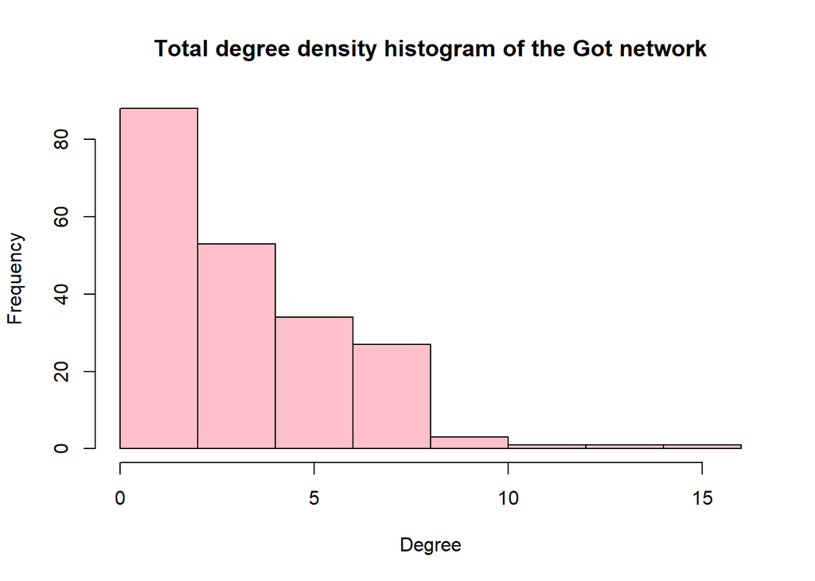

```r
hist(degree(got.network,mode="total"),
     col="pink",
     main="Total degree density histogram of the Got network",
     xlab="Degree",
     freq=TRUE)
```

Degree distribution

```r
degree_distribution(got.network,mode="total")
```

```
##  [1] 0.000000000 0.057692308 0.365384615 0.105769231 0.149038462 0.081730769
##  [7] 0.081730769 0.076923077 0.052884615 0.009615385 0.004807692 0.004807692
## [13] 0.000000000 0.004807692 0.000000000 0.004807692
```

Plot of the distribution

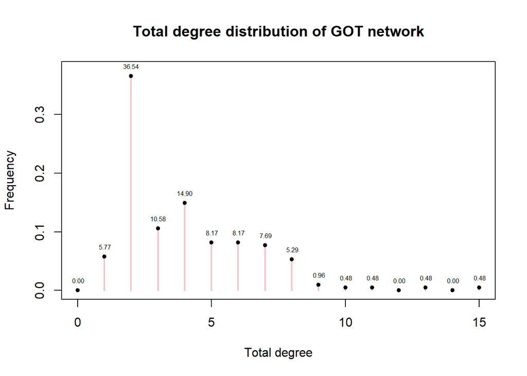

```r
plot(0:max(degree(got.network,mode="total")),
     degree_distribution(got.network,mode="total"),
     ylim=c(0,(max(degree_distribution(got.network,mode="total"))+0.01)),
     col="pink",lwd=2,
     main="Total degree distribution of GOT network",
     xlab="Total degree",
     ylab="Frequency",
     type="h")
points(0:max(degree(got.network,mode="total")),
       degree_distribution(got.network,mode="total"),
       pch=20)
text(0:max(degree(got.network,mode="total")),
     degree_distribution(got.network,mode="total"),
     labels=format(100*degree_distribution(got.network,mode="total"), digits=2), cex=0.5, font=1, pos=3)
```

[figure not shown]

```r
plot(density(degree(got.network,mode="out")),
     col="pink",lwd=2,
     main="Kernel density of total degree distribution of GOT network")
```

Additionally, we can easily identify that there are not aislated characters, since the degree 0 is equal to zero. Moreover, we could say that more than 52% have at least 3 relationships, then we will be able to identy large families and as we have seen the connections among the characters are complex.

# 3 Ice of fire network 3

## 3.1 Check whether the network is connected (strongly and weakly) and obtain the components in both cases.

```r
is_connected(got.network,mode="weak")
```

```
## [1] FALSE
```

Weak components

```r
components(got.network,mode="weak")$csize
```

```
## [1] 189  19
```

```r
components(got.network,mode="weak")$no
```

```
## [1] 2
```

Principal weak components

```r
membership.w <-data.frame(components(got.network,mode="weak")$membership)
membership.w <-membership.w[order(membership.w[,1], decreasing=TRUE),, drop=FALSE]
head(membership.w)
```

```
##                         components.got.network..mode....weak...membership
## Lady of House Stonetree                                                 2
## Lady of House Piper                                                     2
## Lady of House Sunderly                                                  2
## Alannys Harlaw                                                          2
## Quellon Greyjoy                                                         2
## Balon Greyjoy                                                           2
```

```r
is_connected(got.network,mode="strong")
```

```
## [1] FALSE
```

Weak components

```r
components(got.network,mode="strong")$csize
```

```
##   [1] 1 1 2 1 2 1 1 2 1 2 2 1 1 2 1 1 2 2 1 1 1 1 2 1 1 2 1 4 1 1 1 3 2 2 2 2 2
##  [38] 2 3 2 2 1 1 1 1 2 1 1 1 3 1 1 2 2 1 1 1 1 1 1 1 1 2 1 1 1 2 1 2 2 2 2 3 3
##  [75] 2 1 1 1 2 2 1 2 2 4 1 1 1 1 1 1 1 2 1 1 1 2 1 2 1 4 1 1 1 2 2 2 1 1 2 2 1
## [112] 1 2 1 1 3 2 4 1 2 2 2 1 2 1 4 1 2 5 1
```

```r
components(got.network,mode="strong")$no
```

```
## [1] 130
```

Principal weak components

```r
membership.s <-data.frame(components(got.network,mode="strong")$membership)
membership.s <-membership.s[order(membership.s[,1], decreasing=TRUE),, drop=FALSE]
names(membership.s)[1]<- 'countvar'
library(dplyr)
membership.s2 <- membership.s %>%group_by(countvar)%>% summarise(count=n())
head(membership.s)
```

```
##               countvar
## Robert Arryn       130
## Lysa Arryn         129
## Jon Arryn          129
## Petyr Baelish      129
## Jeyne Royce        129
## Rowena Arryn       129
```

## 3.2 Diameter, path and farthest vertices (strongly and weakly).

```r
get_diameter(got.network,directed=TRUE)
```

```
## + 11/208 vertices, named, from 425c90b:
##  [1] Gilliane Glover             Cregan Stark
##  [3] Brandon Stark son of Cregan Beron Stark
##  [5] Willam Stark                Edwyle Stark
##  [7] Rickard Stark               Eddard Stark
##  [9] Sansa Stark                 Tyrion Lannister
## [11] Tysha
```

```r
diameter(got.network,directed=TRUE)
```

```
## [1] 10
```

```r
farthest_vertices(got.network,directed=TRUE)
```

```
## $vertices
## + 2/208 vertices, named, from 425c90b:
## [1] Gilliane Glover Tysha
##
## $distance
## [1] 10
```

```r
V(got.network)$name[get_diameter(got.network,directed=TRUE)]
```

```
##  [1] "Gilliane Glover"             "Cregan Stark"
##  [3] "Brandon Stark son of Cregan" "Beron Stark"
##  [5] "Willam Stark"                "Edwyle Stark"
##  [7] "Rickard Stark"               "Eddard Stark"
##  [9] "Sansa Stark"                 "Tyrion Lannister"
## [11] "Tysha"
```

```r
get_diameter(got.network,directed=FALSE)
```

```
## + 22/208 vertices, named, from 425c90b:
##  [1] Lia Serry                   Theodore Tyrell
##  [3] Luthor Tyrell son of Moryn  Moryn Tyrell
##  [5] Unknown mother Tyrell       Luthor Tyrell
##  [7] Mace Tyrell                 Margaery Tyrell
##  [9] Tommen Baratheon            Cersei Lannister
## [11] Joanna Lannister            Tyrion Lannister
## [13] Sansa Stark                 Eddard Stark
## [15] Lyarra Stark                Arya Flint
## [17] Rodrik Stark son of Beron   Beron Stark
## [19] Brandon Stark son of Cregan Lynara Stark
## + ... omitted several vertices
```

```r
diameter(got.network,directed=FALSE)
```

```
## [1] 21
```

```r
farthest_vertices(got.network,directed=FALSE)
```

```
## $vertices
## + 2/208 vertices, named, from 425c90b:
## [1] Lia Serry     Robyn Ryswell
##
## $distance
## [1] 21
```

```r
V(got.network)$name[get_diameter(got.network,directed=FALSE)]
```

```
##  [1] "Lia Serry"                   "Theodore Tyrell"
##  [3] "Luthor Tyrell son of Moryn"  "Moryn Tyrell"
##  [5] "Unknown mother Tyrell"       "Luthor Tyrell"
##  [7] "Mace Tyrell"                 "Margaery Tyrell"
##  [9] "Tommen Baratheon"            "Cersei Lannister"
## [11] "Joanna Lannister"            "Tyrion Lannister"
## [13] "Sansa Stark"                 "Eddard Stark"
## [15] "Lyarra Stark"                "Arya Flint"
## [17] "Rodrik Stark son of Beron"   "Beron Stark"
## [19] "Brandon Stark son of Cregan" "Lynara Stark"
## [21] "Jonnel Stark"                "Robyn Ryswell"
```

The results show that this network is not connected in a weakly way which means that there are characters that are not connected at all and that we will have separate groups that can be traduce to subgraphs. In fact, there are two groups in this network which will be formed by two different families since the connections represent the relationships among characters.

Moreover, the complete network is also not strongly connected, which means that we will not have a stage where any vertex is reachable from every other vertex by a directed walk, this is obvius because there are relationships that do not behave in both ways, and it is imposible that the families will be all related.

In this network, we have 130 groups that are indeed strongly connected, these are groups of characters that do relate with each other like spouses for example. The 130 also considers the characters that are strong connected only with themselves, these are 71 characters.

We have also calculate the farthest vertices, the distance among them and the diameter. For the strongly connected we got that the diameter was 11 vertices, the distance was 10 and the farthest vertices the character Gilliane Glover and Tysha. Conversely, for the weakly related, the diameter is higher, as we could expected, where its value is 22 and the farthest vertices, then the larger group of related characters, start with Lia Serry and ends with Robyn Ryswell.